신록예찬's 블로그

# (노트) 액시즈, 제목설정, 축범위설정, 상관계수, 독립

Sep 25, 2021 • 신록예찬 • 5 min read

시각화

- matplotlib으로 (진짜 어렵게) 그림을 그리는 방법
  - 예제1: 액시즈를 이용한 플랏
  - 예제2: 액시즈를 추가하여 서브플랏 그리기 (방법1)
  - 예제3: 액시즈를 이용하여 서브플랏 그리기 (방법2)
  - 예제4: 액시즈를 이용하여 2 $\times$ 2 서브플랏 그리기
  - 예제5: plt.subplots()를 이용하여 2$\times$2 서브플랏 그리기 (복습)
  - 예제6: plt.subplots()를 이용하여 2$\times$2 서브플랏 그리기 -- 액시즈를 객체로 저정하여 컨트롤하기
  - 예제7: plt.subplots()를 이용하여 2$\times$2 서브플랏 그리기 -- fig.axes에서 접근!
- 제목설정
  - 예제1: plt.plot()
  - 예제2: 액시즈의 제목 변경
  - 예제3: subplot에서 각 서브플랏의 제목설정
  - 예제4: 액시즈의 제목 + Figure의 제목
- 축범위 설정
  - 예제1
  - 예제2
- 통계예제
  - 예제1
  - 예제2
  - 예제3
  - 예제2~3으로 알아보는 두 변수의 독립성
  - 예제4
  - 숙제

### matplotlib으로 (진짜 어렵게) 그림을 그리는 방법

#### 예제1: 액시즈를 이용한 플랏

`-` 목표: `plt.plot()`사용하지 않고 아래그림을 그려보자.

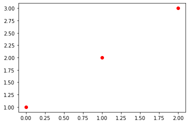

```python
import matplotlib.pyplot as plt
plt.plot([1,2,3],'or')
```

`-` 구조: axis $\subset$ axes $\subset$ figure

- https://matplotlib.org/stable/gallery/showcase/anatomy.html#anatomy-of-a-figure

`-` 전략: 그림을 만들고(도화지 한장 꺼내고) $\to$ 액시즈를 만들고(네모틀 만들고) $\to$ 액시즈에서 그림을 그린다 (히스토그램이든 boxplot이든 산점도-라인플랏이든)

`-` 1단계: 그림객체를 생성한다.

```python
fig=plt.figure()
```

- 그림객체를 출력해봐야 아무것도 안나온다. (아무것도 없으니까)

`-` `fig.`하고 tab을 눌러보자..

- 많은 function과 instance가 있다.
- 당장에 알아야 할것은 `fig.axes`라는 instance 와 `fig.add_axes`라는 function이다.

`-` `fig.axes`에는 figure에 포함된 액시즈가 저장되어있다.

```python
fig.axes
```

```
[]
```

- 지금은 아무것도 없음. 액시즈가 없으니까.

`-` 액시즈를 추가 (방법1)

```python
fig.add_axes([0,0,1,1]) # 액시즈를 추가한다.
```

- 파라메터의미: [l,b,w,h], 좌표의 위치와 크기를 나타내는 파라메터.

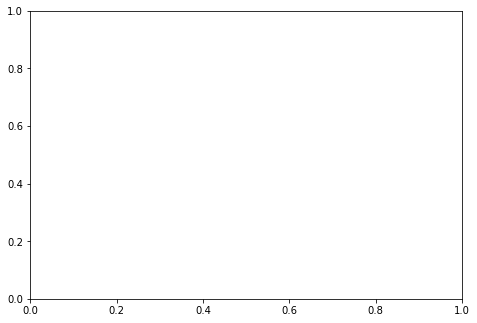

```python
fig
```

- 이제 도화지에 액시즈가 생겼다.

```python
fig.axes
```

```
[<Axes:>]
```

- 액시즈에도 뭔가가 들어가 있다.

`-` 추가된 액시즈에 접근하여 보자.

```python
fig.axes[0]
```

```python
ax1=fig.axes[0]
ax1
```

`-` 기능을 좀 살펴보자.

- `fig.axes[0].` + `tab` 을 눌러보자. (혹은 `ax1.`+`tab`)
- `plot`이라는 메소드가 보인다.
- 우리가 아는 그 플랏인가?

```python
ax1.plot([1,2,3],'or')
```

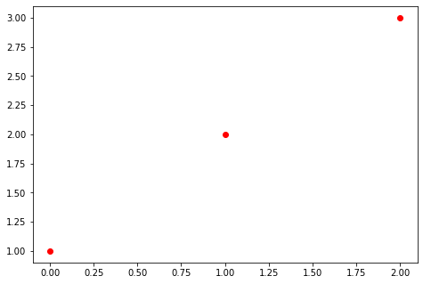

```python
fig
```

#### 예제2: 액시즈를 추가하여 서브플랏 그리기 (방법1)

`-` 목표2: subplot

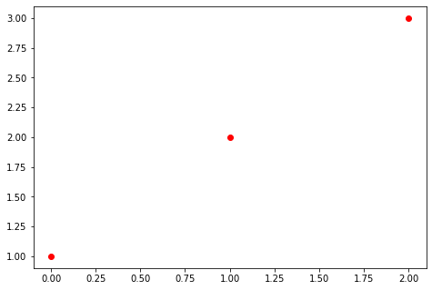

```python
fig ## 현재상황을 체크하기 위해 다시한버 플랏
```

`-` 액시즈추가

```python
fig.add_axes([1,0,1,1]) ## l,b, w,h or x,y, w,h
```

```python
fig.axes
```

```
[<Axes:>, <Axes:>]
```

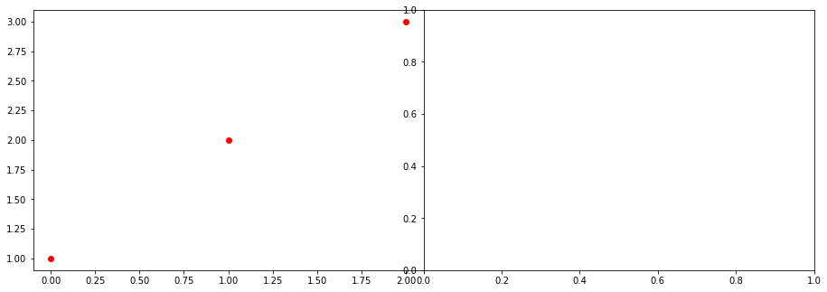

```python
fig
```

`-` 두번째 액시즈에 그림을 그리자.

```python
ax2=fig.axes[1]
```

```python
ax2.plot([1,2,3],'ob')
```

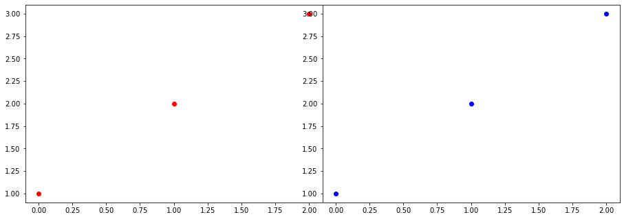

```python
fig
```

#### 예제3: 액시즈를 이용하여 서브플랏 그리기 (방법2)

`-` 레이아웃이 조금 아쉽다..

`-` 다시그려보자.

```python
fig = plt.figure()
```

```python
fig.axes
```

```
[]
```

```python
fig.subplots(1,2)
```

```
array([<AxesSubplot:>, <AxesSubplot:>], dtype=object)
```

```python
fig.axes
```

```
[<AxesSubplot:>, <AxesSubplot:>]
```

```python
ax1, ax2 = fig.axes
```

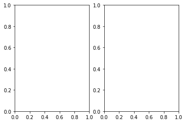

```python
fig
```

```python
ax1.plot([1,2,3],'or')
ax2.plot([1,2,3],'ob')
```

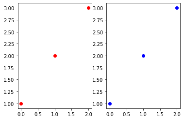

```python
fig
```

- 좀 좁다..

```python
fig.set_figwidth(10)
```

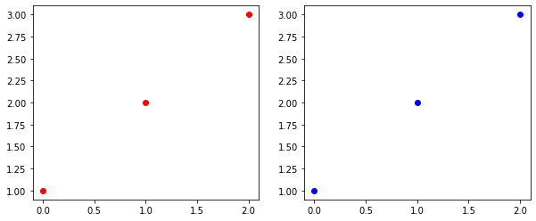

```python
fig
```

#### 예제4: 액시즈를 이용하여 2 $\times$ 2 서브플랏 그리기

```python
fig = plt.figure()
fig.axes
```

```
[]
```

```python
fig.subplots(2,2)
fig.axes
```

```
[<AxesSubplot:>, <AxesSubplot:>, <AxesSubplot:>, <AxesSubplot:>]
```

```python
ax1, ax2, ax3, ax4 = fig.axes
```

```python
ax1.plot([1,2,3],'ob')
ax2.plot([1,2,3],'ok')
ax3.plot([1,2,3],'oy')
ax4.plot([1,2,3],'or')
```

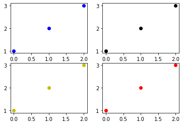

```python
fig
```

#### 예제5: plt.subplots()를 이용하여 2$\times$2 서브플랏 그리기 (복습)

```python
_ , axs = plt.subplots(2,2)
axs[0,0].plot([1,2,3],'ob')
axs[0,1].plot([1,2,3],'or')
axs[1,0].plot([1,2,3],'oy')
axs[1,1].plot([1,2,3],'ok')
```

`-` 이상한 코드

```python
_ , axs = plt.subplots(2,2)
```

```python
axs[0,0].plot([1,2,3],'ob')
axs[0,1].plot([1,2,3],'or')
axs[1,0].plot([1,2,3],'oy')
axs[1,1].plot([1,2,3],'ok')
```

- 이제 그림을 어떻게 그리지???
- 잘 생각해보니까 _ 자리가 figure object 의 자리이다.

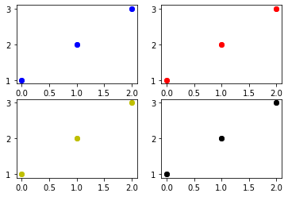

```python
_
```

`-` 좀 더 명시적으로 받으면

```python
fig, axs = plt.subplots(2,2)
```

```python
axs[0,0].plot([1,2,3],'ob')
axs[0,1].plot([1,2,3],'or')
axs[1,0].plot([1,2,3],'oy')
axs[1,1].plot([1,2,3],'ok')
```

```python
fig
```

#### 예제6: plt.subplots()를 이용하여 2$\times$2 서브플랏 그리기 -- 액시즈를 객체로 저정하여 컨트롤하기

```python
fig, axs = plt.subplots(2,2)
```

```python
axs
```

```
array([[<AxesSubplot:>, <AxesSubplot:>],
       [<AxesSubplot:>, <AxesSubplot:>]], dtype=object)
```

```python
(ax1,ax2),(ax3,ax4) = axs
```

```python
ax1.plot([1,2,3],'ob')
ax2.plot([1,2,3],'or')
ax3.plot([1,2,3],'oy')
ax4.plot([1,2,3],'ok')
```

- plt.subplots() 가 리턴하는 axs는 이중리스트의 형식임

```python
(ax1, ax2), (ax3, ax4)= axs
```

```python
ax1.plot([1,2,3],'ob')
ax2.plot([1,2,3],'or')
ax3.plot([1,2,3],'oy')
ax4.plot([1,2,3],'ok')
```

```python
fig
```

#### 예제7: plt.subplots()를 이용하여 2$\times$2 서브플랏 그리기 -- fig.axes에서 접근!

```python
fig, _ = plt.subplots(2,2)
```

```python
ax1, ax2, ax3, ax4 = fig.axes
```

```python
ax1.plot([1,2,3],'ob')
ax2.plot([1,2,3],'or')
ax3.plot([1,2,3],'oy')
ax4.plot([1,2,3],'ok')
```

```python
fig
```

`-` 예제7과 예제4를 비교해볼것. (비슷함)

`-` matplotlib은 그래프를 쉽게 그릴수도 있지만 어렵게 그릴수도 있다.

`-` 오브젝트 하나하나에 접근하여 컨트롤 하는것이 너무 어려우므로 여러가지 축약형이 존재함.

- 사실 그래서 서브플랏을 그리는 방법1,2,3, $\dots$ 과 같은 식으로 정리하여 암기하기 애매하다.

`-` 원리를 깨우치면 다양한 방법을 자유자재로 쓸 수 있다. (자유도가 매우 높음)

### 제목설정

#### 예제1: plt.plot()

```python
x=[1,2,3]
y=[1,2,2]
```

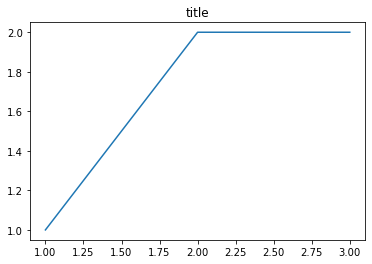

```python
plt.plot(x,y)
plt.title("title")
```

#### 예제2: 액시즈의 제목 변경

`-` 제목을 설정하는 방법2: 액시즈에서!..

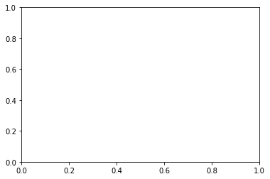

```python
fig = plt.figure()
fig.subplots()
```

```python
ax1=fig.axes[0]
```

```python
ax1.title
```

```python
ax1.set_title('title')
```

```python
ax1.title
```

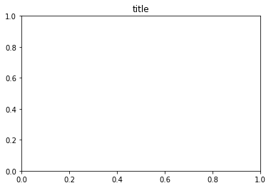

```python
fig
```

`-` 문법을 잘 이해했다면 각 서브플랏의 제목을 설정하는 것도 쉽게 알 수 있다.

#### 예제3: subplot에서 각 서브플랏의 제목설정

`-` subplot의 제목을 설정하여 보자.

```python
fig, ax = plt.subplots(2,2)
```

```python
ax
```

```
array([[<AxesSubplot:>, <AxesSubplot:>],
       [<AxesSubplot:>, <AxesSubplot:>]], dtype=object)
```

```python
(ax1,ax2),(ax3,ax4) = ax
```

```python
ax1.set_title('title 1')
ax2.set_title('title 2')
ax3.set_title('title 3')
ax4.set_title('title 4')
```

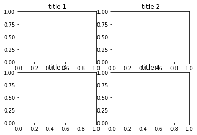

```python
fig
```

`-` 보기싫음 $\to$ 서브플랏 레이아웃 재정렬

```python
fig.tight_layout()
```

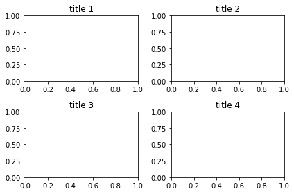

```python
fig
```

#### 예제4: 액시즈의 제목 + Figure의 제목

```python
fig.suptitle('sup title')
```

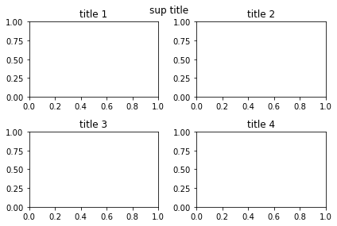

```python
fig
```

`-` 위치를 재조정하자.

```python
fig.tight_layout()
```

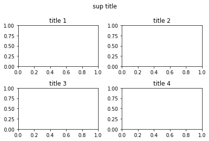

```python
fig
```

### 축범위 설정

#### 예제1

```python
x=[1,2,3]
y=[4,5,6]
```

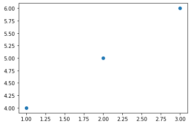

```python
plt.plot(x,y,'o')
```

```
(3.0, 7.0)
```

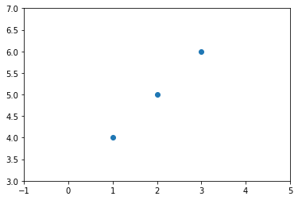

```python
plt.plot(x,y,'o')
plt.xlim(-1,5)
plt.ylim(3,7)
```

`-` 아래와 같이하면..

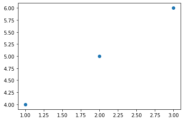

```python
plt.plot(x,y,'o')
```

```
(3.0, 7.0)
```

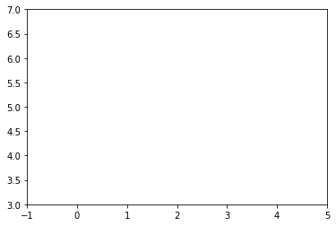

```python
plt.xlim(-1,5)
plt.ylim(3,7)
```

- 점점 불편해진다..

#### 예제2

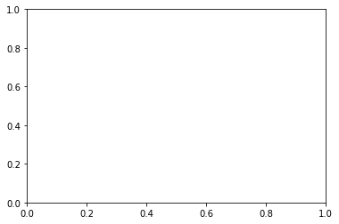

```python
fig = plt.figure()
fig.subplots()
```

```python
a1 =fig.axes[0]
```

```python
a1.plot(np.random.normal(size=100),'o')
```

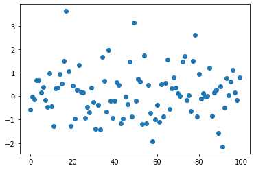

```python
fig
```

```python
a1.set_ylim(-8,8)
```

```
(-8.0, 8.0)
```

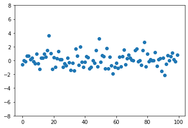

```python
fig
```

### 통계예제

`-` 여러가지 경우의 산점도와 표본상관계수

#### 예제1

```python
import numpy as np
import matplotlib.pyplot as plt
```

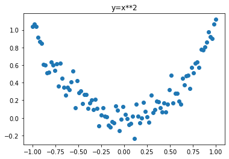

```python
np.random.seed(43052)
x1=np.linspace(-1, 1, 100, endpoint=True)
y1=x1**2+np.random.normal(scale=0.1,size=100)
plt.plot(x1,y1,'o')
plt.title('y=x**2')
```

```python
np.corrcoef(x1,y1)
```

```
array([[1.        , 0.00688718],
       [0.00688718, 1.        ]])
```

`-` (표본)상관계수의 값이 0에 가까운 것은 두 변수 사이에 직선관계 약한 것을 시사하는 것이지 아무런 함수관계가 없음을 의미하는 것은 아니다.

#### 예제2

`-` 아래와 같은 자료를 고려하자.

```python
np.random.seed(43052)
x2=np.random.uniform(low=-1,high=1,size=10000)
y2=np.random.uniform(low=-1,high=1,size=10000)
```

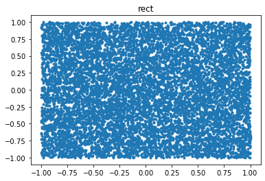

```python
plt.plot(x2,y2,'.')
plt.title('rect')
```

```python
np.corrcoef(x2,y2)
```

```
array([[ 1.        , -0.01748844],
       [-0.01748844,  1.        ]])
```

#### 예제3

```python
np.random.seed(43052)
_x3=np.random.uniform(low=-1,high=1,size=10000)
_y3=np.random.uniform(low=-1,high=1,size=10000)
```

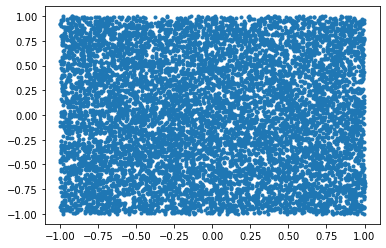

```python
plt.plot(_x3,_y3,'.')
```

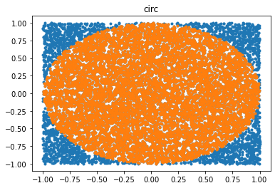

```python
radius = _x3**2+_y3**2
x3=_x3[radius < 1]
y3=_y3[radius < 1]
plt.plot(_x3,_y3,'.')
plt.plot(x3,y3,'.')
plt.title('circ')
```

```python
np.corrcoef(x3,y3)
```

```
array([[ 1.        , -0.00255104],
       [-0.00255104,  1.        ]])
```

#### 예제2~3으로 알아보는 두 변수의 독립성

`-` 예제2,3에 대하여 아래와 같은 절차를 고려하여 보자.

(1) $X \in [-h,h]$일 경우 $Y$의 분포를 생각해보자. 그리고 히스토그램을 그려보자.

(2) $X \in [0.9-h,0.9+h]$일 경우 $Y$의 분포를 생각해보자. 그리고 히스토그램을 그려보자.

(3) (1)-(2)를 비교하여 보자.

`-` 예제2의 경우를 먼저 살펴보자.

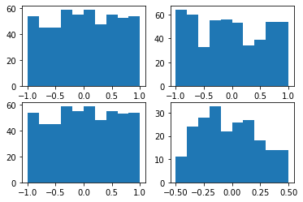

```python
h=0.05
_, axs = plt.subplots(2,2)
axs[0,0].hist(y2[(x2> -h)*(x2< h)]) ## 예제2
axs[0,1].hist(y2[(x2> 0.9-h)*(x2< 0.9+h)]) ## 예제2
axs[1,0].hist(y3[(x3> -h)*(x3< h)]) ## 예제3
axs[1,1].hist(y3[(x3> 0.9-h)*(x3< 0.9+h)]) ## 예제3
```

```
(-1.1, 1.1)
```

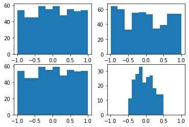

```python
h=0.05
_, axs = plt.subplots(2,2)
axs[0,0].hist(y2[(x2> -h)*(x2< h)]) ## 예제2
axs[0,0].set_xlim(-1.1,1.1)
axs[0,1].hist(y2[(x2> 0.9-h)*(x2< 0.9+h)]) ## 예제2
axs[0,1].set_xlim(-1.1,1.1)
axs[1,0].hist(y3[(x3> -h)*(x3< h)]) ## 예제3
axs[1,0].set_xlim(-1.1,1.1)
axs[1,1].hist(y3[(x3> 0.9-h)*(x3< 0.9+h)]) ## 예제3
axs[1,1].set_xlim(-1.1,1.1)
```

#### 예제4

`-` 아래와 같은 자료를 고려하자.

```python
np.random.seed(43052)
x4=np.random.normal(scale=1,size=10000)
y4=np.random.normal(scale=1,size=10000)
```

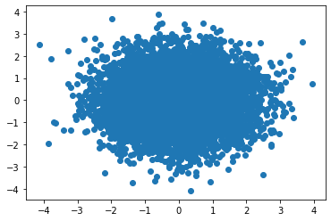

```python
plt.plot(x4,y4,'o')
```

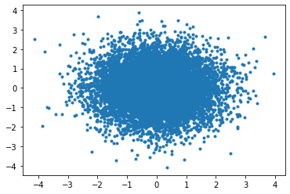

```python
plt.plot(x4,y4,'.')
```

`-` 디자인적인 측면에서 올바르지 않음. (밀도가 왜곡되어 보인다)

`-` 아래와 같은 그림이 더 우수하다. (밀도를 표현하기 위해 `투명도`라는 개념을 도입함)

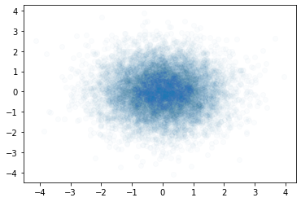

```python
plt.scatter(x4,y4,alpha=0.02)
```

```python
np.corrcoef(x4,y4)
```

```
array([[ 1.        , -0.01007718],
       [-0.01007718,  1.        ]])
```

`-` 독립?

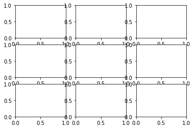

```python
h=0.05
fig, _ = plt.subplots(3,3)
```

```python
fig.tight_layout()
```

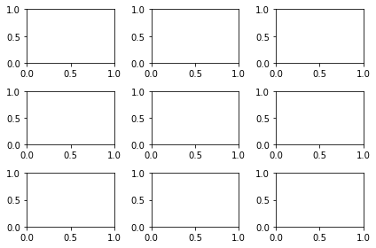

```python
fig
```

```python
fig.set_figwidth(10)
fig.set_figheight(10)
```

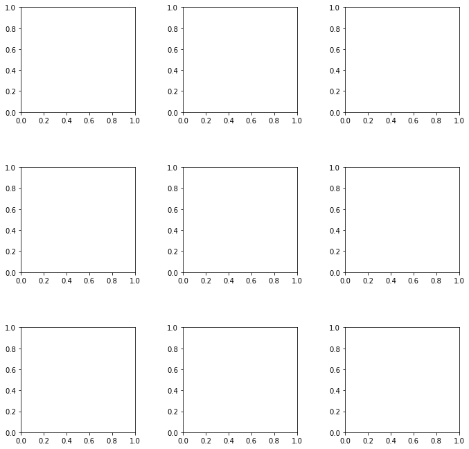

```python
fig
```

```python
fig.axes
```

```
[<AxesSubplot:>,
 <AxesSubplot:>,
 <AxesSubplot:>,
 <AxesSubplot:>,
 <AxesSubplot:>,
 <AxesSubplot:>,
 <AxesSubplot:>,
 <AxesSubplot:>,
 <AxesSubplot:>]
```

```python
k=np.linspace(-2,2,9)
k
```

```
array([-2. , -1.5, -1. , -0.5,  0. ,  0.5,  1. ,  1.5,  2. ])
```

```python
h=0.2
for i in range(9):
    fig.axes[i].hist(y4[(x4> k[i]-h)*(x4< k[i]+h)])
```

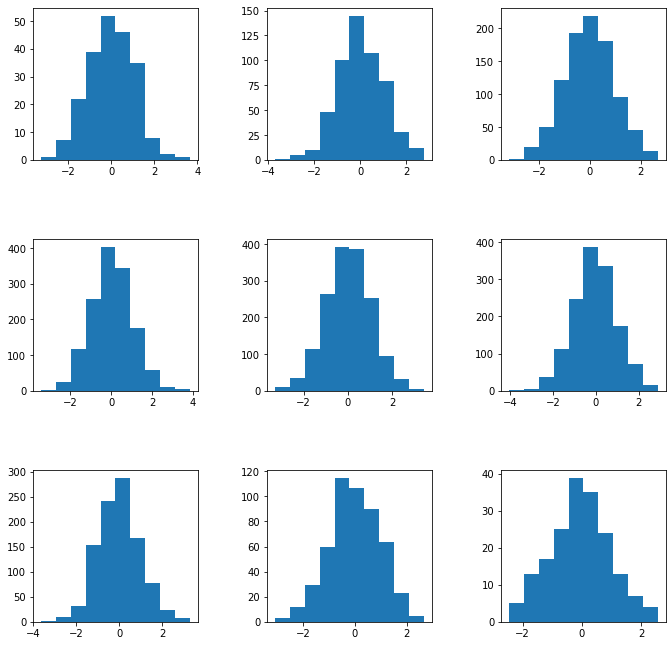

```python
fig
```

`-` 빈도는 다르지만 분포의 모양은 같다!

#### 숙제

`-` 아래그림에서 색깔을 붉은색으로 바꿔보라. (주의: 수업시간에 알려주지 않음)

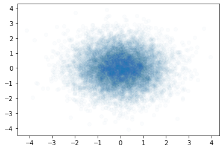

```python
plt.scatter(x4,y4,alpha=0.02)
```

```python
plt.scatter(x4,y4,alpha=0.02,'r')
```

```
  File "<ipython-input-267-a66653eb7bba>", line 1
    plt.scatter(x4,y4,alpha=0.02,'r')
                                 ^
SyntaxError: positional argument follows keyword argument
```

`-` 힌트: 구글링 or plt.scatter? 사용

`-` 답:

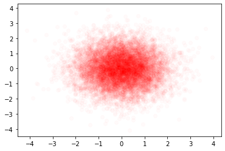

```python
plt.scatter(x4,y4,alpha=0.02,c='red')
```